# Myocardin splicing: differential gene expression analysis

Dmytro Kryvokhyzha

LUDC Bioinformatics Unit  
dmytro.kryvokhyzha@med.lu.se

04 december, 2020

## Dependencies

```r
library(DESeq2)
library(RColorBrewer)
library(ggplot2)
library(mygene)
library(sm)
library(reshape2)
```

## Data

Load the raw counts data:

```r
read_counts <- read.table(gzfile('results/tables/featureCounts/featureCounts_counts_gene.csv.gz'),
                          header=T, row.names='gene')
```

Extract gene length:

```r
gene_length <- read_counts$length
read_counts$length <- NULL
names(gene_length) <- row.names(read_counts)
```

Sort columns:

```r
read_counts <- read_counts[,sort(names(read_counts))]
knitr::kable(head(read_counts))
```

|  | CMV1 | CMV2 | CMV4 | CMV5 | MYO1 | MYO2 | MYO4 | MYO5 |
| --- | --- | --- | --- | --- | --- | --- | --- | --- |
| ENSG00000000003.15 | 1286 | 1115 | 1342 | 887 | 699 | 697 | 654 | 578 |
| ENSG00000000005.6 | 0 | 0 | 1 | 0 | 335 | 403 | 207 | 276 |
| ENSG00000000419.13 | 2842 | 2459 | 2846 | 2059 | 1906 | 1912 | 1759 | 1544 |
| ENSG00000000457.14 | 1030 | 926 | 1056 | 770 | 1100 | 1034 | 1092 | 783 |
| ENSG00000000460.17 | 394 | 368 | 456 | 282 | 276 | 247 | 286 | 187 |
| ENSG00000000938.13 | 1 | 0 | 2 | 1 | 0 | 0 | 2 | 3 |

### Library size & counts distribution

Library size barplot & counts distribution boxplot

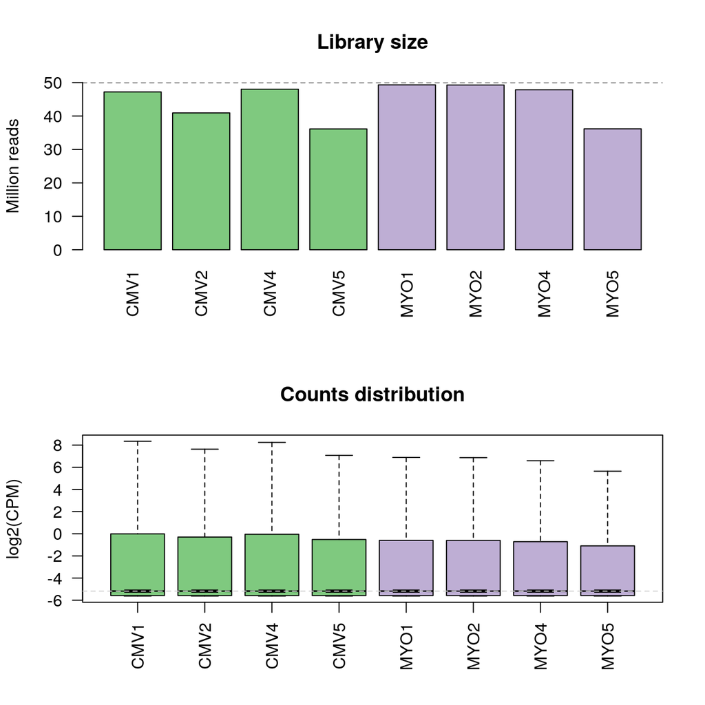

```r
colors2 <- brewer.pal(3, 'Accent')[c(1,2)]
condition_color <- c(rep(colors2[1], 4),rep(colors2[2], 4))
par(mfcol=c(2,1))
# Library size
libsize <- colSums(read_counts)/1000000
barplot(libsize,
        ylim = c(0,50),
        names.arg=names(read_counts),
        col= condition_color,
        ylab = 'Million reads',
        main = 'Library size',
        las =2)
abline(h=50, lty=2)
# counts distribution boxplot
logCPM <- log2((read_counts+1)/colSums(read_counts+1)*1e+06)
boxplot(logCPM,
        xlab='',
        ylab='log2(CPM)',
        notch   =T,
        col = condition_color,
        outline=FALSE,
        main = 'Counts distribution',
        las=2)
abline(h=median(as.matrix(logCPM)), lty=2, col='lightgrey')
```

Samples density plot

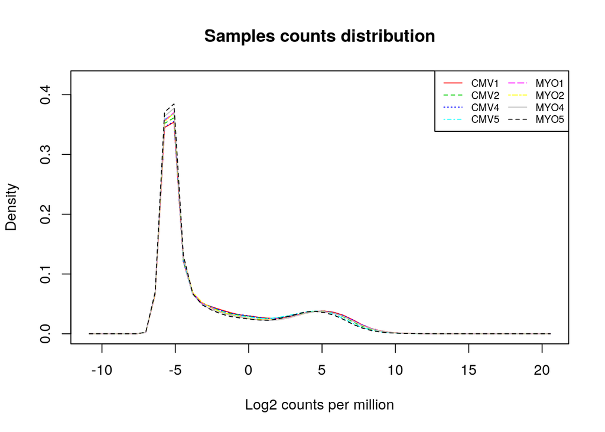

```r
condition <- c(rep('control', 4), rep('treatment', 4))
logCPM_dens <- data.frame(logCPM=as.vector(t(logCPM)),
                          samples=rep(colnames(logCPM), dim(logCPM)[1]),
                          condition=rep(condition, dim(logCPM)[1]))
# samples density plot
sm.density.compare(logCPM_dens$logCPM,
                   logCPM_dens$samples,
                   xlab='Log2 counts per million')
title(main='Samples counts distribution')
colfill<-c(2:(2+length(levels(logCPM_dens$samples))))
legend('topright',
       levels(logCPM_dens$samples),
       col=colfill,
       lty=c(1:length(logCPM_dens$samples)),
       lwd=1,
       ncol=2,
       cex=0.7)
```

condition density plot

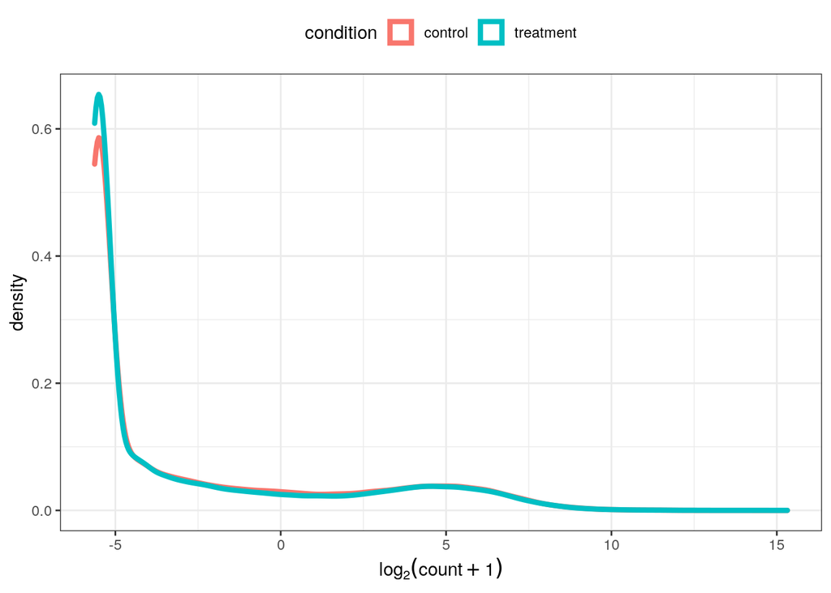

```r
ggplot(logCPM_dens, aes(x = logCPM, colour = condition)) +
  geom_density(alpha = 0.5, size = 1.5) + theme_bw() +
  theme(legend.position = 'top') + xlab(expression(log[2](count + 1)))
```

### DESeq object

Create DESeq object:

```r
colData <- data.frame(samples=names(read_counts), condition)
dds <- DESeqDataSetFromMatrix(countData = read_counts,
                              colData = colData,
                              design= ~ condition)
```

Remove lowly expressed genes

```r
keep <- rowSums(counts(dds)) >= dim(dds)[2]
dds <- dds[keep,]
sum(keep)
```

```
## [1] 26874
```

Perform variance stabilizing transformation

```r
vst <- vst(dds, blind=T)
dds <- DESeq(dds)
```

### Dispersion plot

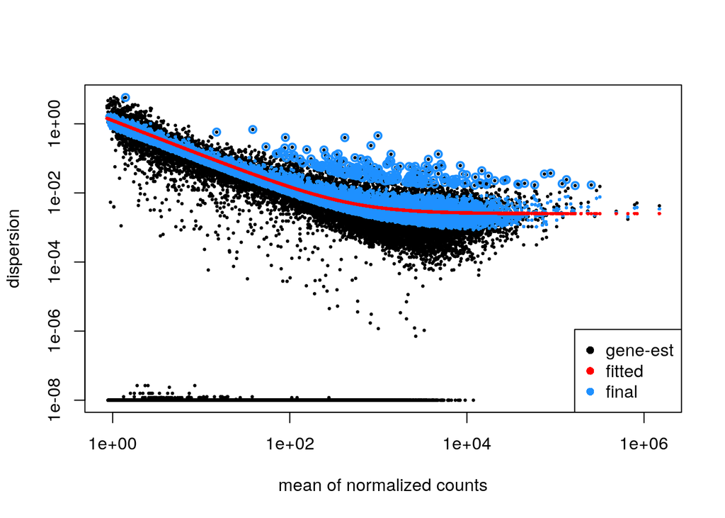

```r
plotDispEsts(dds)
```

### MYOCD expression

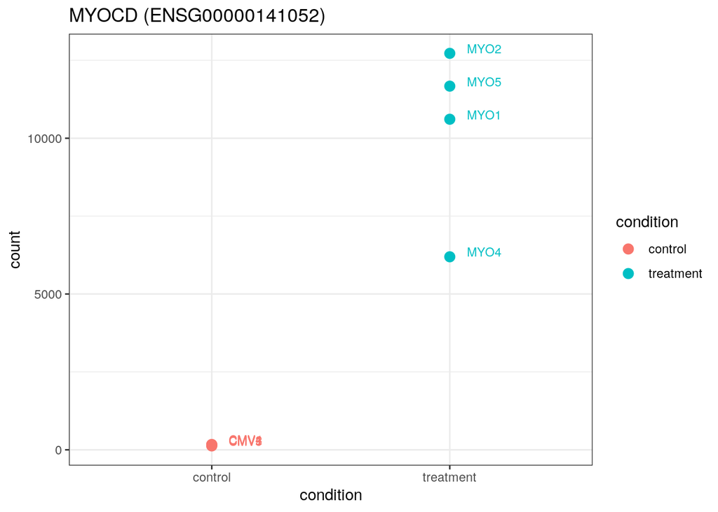

```r
plotKD <- plotCounts(dds, gene='ENSG00000141052.18',
                     intgroup='condition',
                     returnData=TRUE)
ggplot(plotKD, aes(x=condition, y=count, colour = condition)) +
  theme_bw() +
  ggtitle('MYOCD (ENSG00000141052)') +
  geom_point(size=3) +
  geom_text(label=rownames(plotKD), size=3, hjust=-0.5, vjust=0)
```

This image is also available as a file `results/figures/MYOCD_expression.pdf`

### PCA

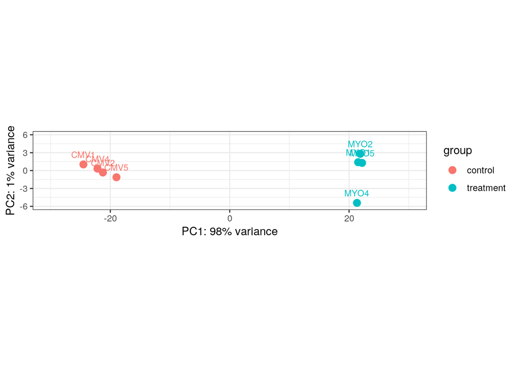

```r
plotPCA(vst, intgroup='condition') +
  theme_bw() +
  scale_x_continuous(limits = c(-30, 30)) +
  scale_y_continuous(limits = c(-6, 6)) +
  geom_text(label=vst$samples, size=3, hjust=0.5, vjust=-1)
```

## Differential expression

Significance level

```r
signLevel <- 0.01
```

### Results

```r
res <- results(dds,
               contrast=c('condition',  'treatment', 'control'),
               alpha=signLevel)
res <- res[order(res$padj),]
summary(res)
```

```
##
## out of 26874 with nonzero total read count
## adjusted p-value < 0.01
## LFC > 0 (up)       : 5626, 21%
## LFC < 0 (down)     : 5737, 21%
## outliers [1]       : 0, 0%
## low counts [2]     : 1043, 3.9%
## (mean count < 1)
## [1] see 'cooksCutoff' argument of ?results
## [2] see 'independentFiltering' argument of ?results
```

Volcano plot:

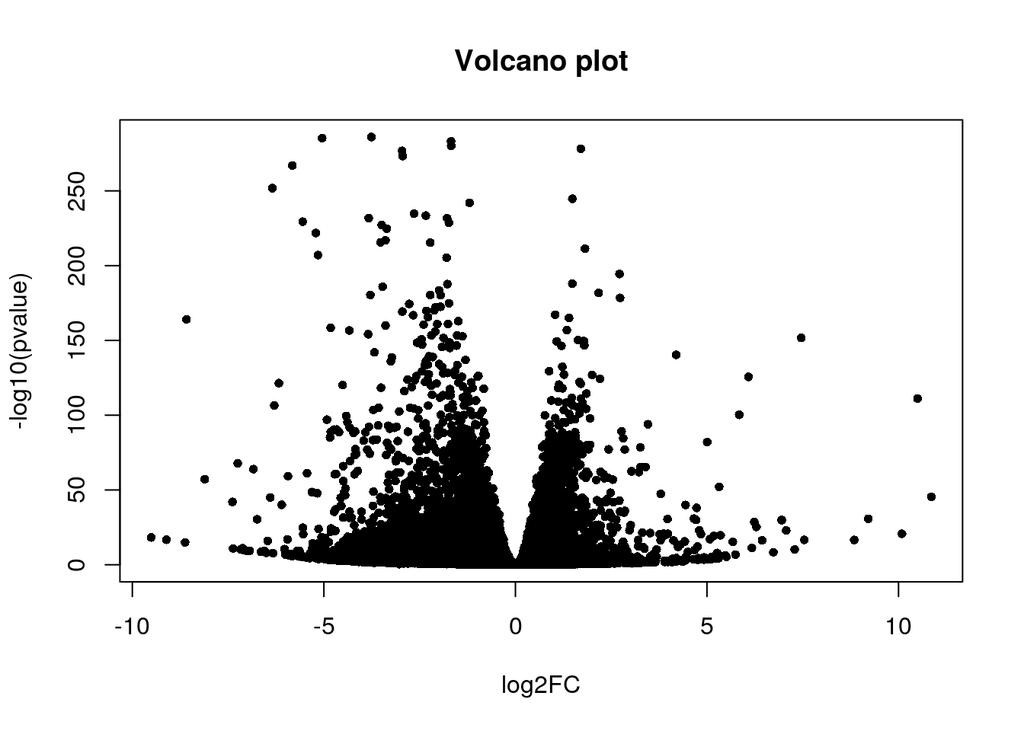

```r
plot(res$log2FoldChange, -log10(res$padj),
     main='Volcano plot',
     xlab='log2FC',
     ylab='-log10(pvalue)',
     pch=16, cex=0.8)
```

### Annotate with gene names and summary

Add TPM column (takes a while):

```r
sum(names(gene_length) != row.names(read_counts)) # = 0
```

```
## [1] 0
```

```r
read_counts_length <- read_counts/gene_length
dds_tpm <- t(t(read_counts_length)*1e6/colSums(read_counts_length))
colnames(dds_tpm) <- paste(colnames(dds_tpm), 'tpm', sep = '_')
# calculate means
mean_tpm <- aggregate(t(dds_tpm), list(condition), mean)
# transform the results
mean_tpm_names <- as.character(mean_tpm[,1])
mean_tpm_val <- as.data.frame(t(mean_tpm[,-1]))
colnames(mean_tpm_val) <- paste(mean_tpm_names, 'tpm', sep = '_')
# merge
res_mean_tpm_val <- merge(as.data.frame(res), mean_tpm_val, by=0, all.x = T)
rownames(res_mean_tpm_val) <- res_mean_tpm_val$Row.names
res_mean_tpm_val$Row.names <- NULL
res_tpm_mean <- merge(res_mean_tpm_val, dds_tpm, by=0, all.x = T)
rownames(res_tpm_mean) <- res_tpm_mean$Row.names
res_tpm_mean$Row.names <- NULL
# head(res_tpm_mean)
```

Retrieve the annotation information (takes a while):

```r
gene_renamed <- gsub("\\..*","", rownames(res_tpm_mean))
annotAll <- queryMany(unique(gene_renamed),
                      scopes='ensembl.gene',
                      fields='symbol,name,summary', # pathway.kegg.id,go
                      return.as='DataFrame',
                      species='human',
                      returnall=FALSE)
```

```
## Finished
## Pass returnall=TRUE to return lists of duplicate or missing query terms.
```

```r
# add full gene names
gene2renamed <- data.frame(gene=rownames(res_tpm_mean), query=gene_renamed)
annotAll <- merge(annotAll, gene2renamed, by='query')
# remove duplicated and not found rows:
duplNoSumNoFound <- which(duplicated(annotAll$query))
annot <- as.data.frame(annotAll[-duplNoSumNoFound,
                                c('gene', 'query', 'symbol', 'name', 'summary')])
rownames(annot) <- annot$gene
#head(annot, 2)
```

Merge the annotation with the results table:

```r
res_tpm_mean_annot <- merge(res_tpm_mean, annot, by=0, all.x = T)
res_tpm_mean_annot$Row.names <- NULL
res_tpm_mean_annot$query <- NULL
front_columns <- c('gene', 'baseMean','log2FoldChange', 'lfcSE', 'stat','pvalue','padj',
                   'control_tpm', 'treatment_tpm',
                   'symbol', 'name', 'summary')
back_columns <-  colnames(res_tpm_mean_annot)[which(!(colnames(res_tpm_mean_annot) %in% front_columns))]
res_tpm_mean_annot <- res_tpm_mean_annot[,c(front_columns, back_columns)]
# order by padj
res_tpm_mean_annot <- res_tpm_mean_annot[order(res_tpm_mean_annot$padj),]
rownames(res_tpm_mean_annot) <- res_tpm_mean_annot$gene
```

### Plot significant genes

Top 30 genes

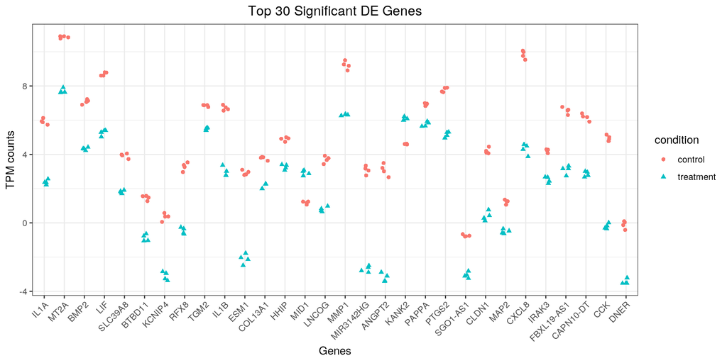

```r
# Get top genes
ntop <- 30
ntop_genes <- c(1:ntop)
sign_genes_names <- res_tpm_mean_annot$symbol[ntop_genes]
res_tpm_all <- res_tpm_mean_annot[!duplicated(res_tpm_mean_annot$gene),
                                    grep('CMV|MY', names(res_tpm_mean_annot))]
countsNorm <- log2(as.matrix(res_tpm_all[ntop_genes,]))
colnames(countsNorm) <- gsub('_tpm', '', colnames(countsNorm))
rownames(countsNorm) <- sign_genes_names
# melt
top_genes_norm_melt <- melt(countsNorm)
colnames(top_genes_norm_melt) <- c('gene', 'samplename', 'normalized_counts')
# add annonation
meta_exp_levels <- data.frame(condition=condition, samplename=names(read_counts))
top_genes_norm <- merge(top_genes_norm_melt, meta_exp_levels, by='samplename')
# order by genes
top_genes_norm <- top_genes_norm[order(top_genes_norm$gene),]
# plot
ggplot(top_genes_norm) +
        geom_point(aes(x = gene,
                       y = normalized_counts,
                       color = condition,
                       shape=condition),
                   position=position_jitter(w=0.2,h=0)) +
        xlab("Genes") +
        ylab("TPM counts") +
        ggtitle(paste("Top ", ntop, " Significant DE Genes", sep = "")) +
        theme_bw() +
    theme(axis.text.x = element_text(angle = 45, hjust = 1)) +
    theme(plot.title=element_text(hjust=0.5))
```

## Positive control genes

*MYH11*, *MCAM* and *SYNM* can be used to verify that *MYOCD* over-expression worked

There are also much less responsive target genes: *RRAS*, *RBPMS*, and *RBPMS2*.

We also have qPCR information in *MYH11, MCAM, KCNMB1*.

Differentially splicing of the following genes is of interest: *ACTN1, SMTN, NFIC, BICD2, TEAD1, TPM1, TPM2, PDLIM7, FHL1, CSR2, TGFB11, PKD1, MYL6, PDLIM5, FLNA, MBNL1, ZFR, FNBP1, SORBS1, PIP5K1C, TNRC18, SVIL, KLHL42, LARGE1, MICAL3*

### Table

```r
interesting_genes <- c('MYOCD', 'MYH11', 'MCAM', 'SYNM', 'RRAS', 'RBPMS', 'RBPMS2', 'KCNMB1',
                       'ACTN1', 'SMTN', 'NFIC', 'BICD2', 'TEAD1', 'TPM1', 'TPM2',
                       'PDLIM7', 'FHL1', 'CSR2', 'TGFB11', 'PKD1', 'MYL6', 'PDLIM5',
                       'FLNA', 'MBNL1', 'ZFR', 'FNBP1', 'SORBS1', 'PIP5K1C',
                       'TNRC18', 'SVIL', 'KLHL42', 'LARGE1', 'MICAL3')
ntop_genes <- as.character(res_tpm_mean_annot$gene[which(res_tpm_mean_annot$symbol
                                                         %in% interesting_genes)])
res_tpm_mean_annot_interesting <- res_tpm_mean_annot[ntop_genes,]
res_tpm_mean_annot_interesting$pvalue <- format(res_tpm_mean_annot_interesting$pvalue, digits = 3)
res_tpm_mean_annot_interesting$padj <- format(res_tpm_mean_annot_interesting$pvalue, digits = 3)
col_interesting <- c("symbol", "log2FoldChange", "control_tpm","treatment_tpm", "pvalue", "padj")
knitr::kable(res_tpm_mean_annot_interesting[,col_interesting])
```

|  | symbol | log2FoldChange | control_tpm | treatment_tpm | pvalue | padj |
| --- | --- | --- | --- | --- | --- | --- |
| ENSG00000133392.18 | MYH11 | 7.4615378 | 0.1021954 | 18.4441514 | 5.34e-155 | 5.34e-155 |
| ENSG00000141052.18 | MYOCD | 6.0840860 | 0.4048833 | 28.0005129 | 9.09e-129 | 9.09e-129 |
| ENSG00000152601.17 | MBNL1 | 0.9366656 | 31.3638595 | 61.9517991 | 7.83e-113 | 7.83e-113 |
| ENSG00000022267.19 | FHL1 | 1.3186884 | 11.9708383 | 30.7455745 | 2.77e-111 | 2.77e-111 |
| ENSG00000076706.17 | MCAM | 5.0059159 | 2.2510360 | 73.8391148 | 1.17e-84 | 1.17e-84 |
| ENSG00000196924.18 | FLNA | 1.2299066 | 1469.0529640 | 3551.1324485 | 3.58e-82 | 3.58e-82 |
| ENSG00000072110.14 | ACTN1 | 0.9178237 | 90.0287117 | 175.5499707 | 8.30e-60 | 8.30e-60 |
| ENSG00000163110.15 | PDLIM5 | 0.6165895 | 54.0929991 | 85.5432030 | 4.70e-50 | 4.70e-50 |
| ENSG00000198467.16 | TPM2 | 1.5427359 | 239.2755613 | 717.7813483 | 3.24e-27 | 3.24e-27 |
| ENSG00000182253.15 | SYNM | 1.9889354 | 2.8663100 | 11.6645305 | 1.29e-24 | 1.29e-24 |
| ENSG00000187239.17 | FNBP1 | 0.4666869 | 8.9709370 | 12.8036197 | 1.50e-23 | 1.50e-23 |
| ENSG00000095637.22 | SORBS1 | 1.4356146 | 4.5175480 | 12.5796904 | 2.00e-22 | 2.00e-22 |
| ENSG00000008710.20 | PKD1 | 0.5025564 | 55.8238556 | 81.4961120 | 6.88e-22 | 6.88e-22 |
| ENSG00000196923.14 | PDLIM7 | 0.6001265 | 185.1460495 | 289.5537216 | 1.75e-21 | 1.75e-21 |
| ENSG00000182095.14 | TNRC18 | 0.3963105 | 17.3994539 | 23.6365207 | 5.01e-20 | 5.01e-20 |
| ENSG00000145936.9 | KCNMB1 | 3.7912837 | 0.0701836 | 0.9869697 | 4.39e-18 | 4.39e-18 |
| ENSG00000141905.19 | NFIC | 0.3840563 | 16.3483107 | 22.0216000 | 1.52e-17 | 1.52e-17 |
| ENSG00000187079.19 | TEAD1 | 0.3028155 | 25.1613301 | 32.0405525 | 3.22e-15 | 3.22e-15 |
| ENSG00000186111.10 | PIP5K1C | 0.3504624 | 18.1577484 | 23.8974270 | 2.98e-12 | 2.98e-12 |
| ENSG00000140416.23 | TPM1 | 0.5179030 | 473.8558480 | 698.5479167 | 6.70e-11 | 6.70e-11 |
| ENSG00000197321.15 | SVIL | 0.2784446 | 6.6804011 | 8.3473739 | 1.06e-09 | 1.06e-09 |
| ENSG00000126458.4 | RRAS | 0.3373790 | 88.2917518 | 114.8211507 | 1.64e-09 | 1.64e-09 |
| ENSG00000087448.11 | KLHL42 | 0.3367823 | 28.8826389 | 37.5430891 | 8.28e-09 | 8.28e-09 |
| ENSG00000157110.16 | RBPMS | 0.2107243 | 20.9556977 | 25.0368261 | 4.89e-07 | 4.89e-07 |
| ENSG00000092841.19 | MYL6 | 0.2942517 | 568.4925550 | 716.8743457 | 5.85e-06 | 5.85e-06 |
| ENSG00000243156.9 | MICAL3 | 0.1973809 | 5.4769421 | 6.4876685 | 4.28e-04 | 4.28e-04 |
| ENSG00000056097.16 | ZFR | 0.1023801 | 20.1003569 | 22.2571897 | 9.99e-03 | 9.99e-03 |
| ENSG00000133424.21 | LARGE1 | -0.1508060 | 2.5488153 | 2.3732431 | 2.07e-02 | 2.07e-02 |
| ENSG00000185963.14 | BICD2 | 0.0894916 | 11.1719376 | 12.2321571 | 1.20e-01 | 1.20e-01 |
| ENSG00000183963.18 | SMTN | 0.0456267 | 23.1330204 | 24.5520357 | 5.22e-01 | 5.22e-01 |
| ENSG00000166831.9 | RBPMS2 | 0.1156711 | 0.1103582 | 0.1223065 | 7.51e-01 | 7.51e-01 |

### Plot

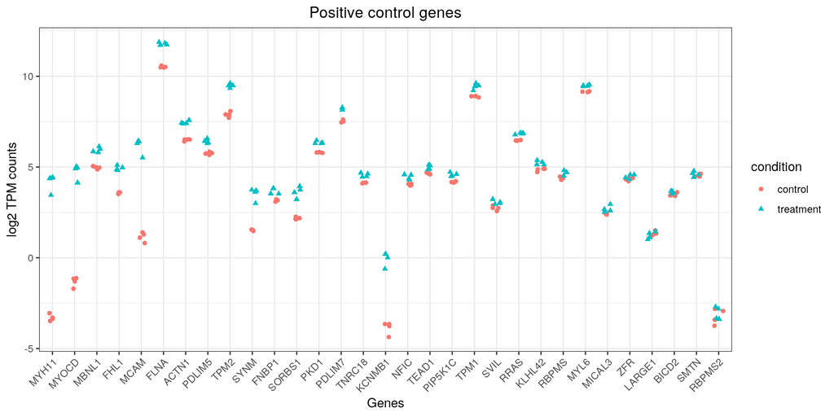

```r
# Get top genes
res_tpm_all <- res_tpm_mean_annot_interesting[ntop_genes,grep('CMV|MY|symbol', names(res_tpm_mean_annot_interesting))]
rownames(res_tpm_all) <- res_tpm_all$symbol
res_tpm_all$symbol <- NULL
countsNorm <- log2(as.matrix(res_tpm_all))
colnames(countsNorm) <- gsub('_tpm', '', colnames(countsNorm))
# melt
top_genes_norm_melt <- melt(countsNorm)
colnames(top_genes_norm_melt) <- c('gene', 'samplename', 'normalized_counts')
# add annonation
meta_exp_levels <- data.frame(condition=condition, samplename=names(read_counts))
top_genes_norm <- merge(top_genes_norm_melt, meta_exp_levels, by='samplename')
# order by genes
top_genes_norm <- top_genes_norm[order(top_genes_norm$gene),]
# plot
ggplot(top_genes_norm) +
        geom_point(aes(x = gene,
                       y = normalized_counts,
                       color = condition,
                       shape=condition),
                   position=position_jitter(w=0.2,h=0)) +
        xlab("Genes") +
        ylab("log2 TPM counts") +
        ggtitle('Positive control genes') +
        theme_bw() +
    theme(axis.text.x = element_text(angle = 45, hjust = 1)) +
    theme(plot.title=element_text(hjust=0.5))
```

## Write results

```r
filePath <- 'results/tables/diff_expression_genes/'
dir.create(filePath, showWarnings = FALSE)
# all results
write.table(res_tpm_mean_annot,
            paste(filePath, 'DESeq_all.csv', sep=''),
            quote = F,
            row.names = F,
            sep = '\t')
# only candidate genes
write.table(res_tpm_mean_annot_interesting,
            paste(filePath, 'DESeq_interesting.csv', sep=''),
            row.names = F,
            quote = F,
            sep = '\t')
```